# Diversity Check_Absent Species

Shaoqian Huang

2026-09-28

## Aims

In this document, we aim to pinpoint the issue of the proposed diversity measure, $\hat{\boldsymbol{\mu}}_B^{\top}\boldsymbol{D}\hat{\boldsymbol{\mu}}_B$, when some species are have low abundance or almost absent at certain communities, and explore some potential solutions, including modifying the models by including row effects, modifying the model by putting unimportant species effects into random effects, and explore another measure $\hat{\boldsymbol{\mu}}^{\top}\boldsymbol{D}\hat{\boldsymbol{\mu}}$.

## DGM

### Set up parameters

```r
r <- 128 # sample size in each com
p <- 5 # the number of species
q <- 6 # the number of communities
## Mean abundance
mu=matrix(c(0.8,0.0001,0.8,0.0001,0.8,0.0001,0.8,0.8,0.0001,0.8,0.8,0.8,0.0001,0.0001,0.8,0.8,0.8,0.8,0.0001,0.0001,2/3,1/9,2/3,1/9,2/3, 0.8, 0.0001, 0.0001, 0.8, 0.8),ncol=6)
rownames(mu)=LETTERS[1:5]
colnames(mu)=1:q
mu <- t(mu)
print(mu)
```

```
##           A         B         C         D         E
## 1 0.8000000 0.0001000 0.8000000 0.0001000 0.8000000
## 2 0.0001000 0.8000000 0.8000000 0.0001000 0.8000000
## 3 0.8000000 0.8000000 0.0001000 0.0001000 0.8000000
## 4 0.8000000 0.8000000 0.8000000 0.0001000 0.0001000
## 5 0.6666667 0.1111111 0.6666667 0.1111111 0.6666667
## 6 0.8000000 0.0001000 0.0001000 0.8000000 0.8000000
```

```r
## Logit scale of mean abundance
eta <- logit(mu)
print(eta)
```

```
##            A         B          C         D          E
## 1  1.3862944 -9.210240  1.3862944 -9.210240  1.3862944
## 2 -9.2102404  1.386294  1.3862944 -9.210240  1.3862944
## 3  1.3862944  1.386294 -9.2102404 -9.210240  1.3862944
## 4  1.3862944  1.386294  1.3862944 -9.210240 -9.2102404
## 5  0.6931472 -2.079442  0.6931472 -2.079442  0.6931472
## 6  1.3862944 -9.210240 -9.2102404  1.386294  1.3862944
```

```r
## Distance Matrix
D=matrix(c(0,1,2,3,4,1,0,2,3,4,2,2,0,3,4,3,3,3,0,4,4,4,4,4,0),ncol=5)
colnames(D)=rownames(D)=LETTERS[1:5]
print(D)
```

```
##   A B C D E
## A 0 1 2 3 4
## B 1 0 2 3 4
## C 2 2 0 3 4
## D 3 3 3 0 4
## E 4 4 4 4 0
```

```r
## An orthogonal projection matrix
J <- diag(rep(1, p)) -  1/p * matrix(1, p, p)

## eta_B and mu_eta_B
eta_B <- eta %*% J
mu_eta_B <- expit(eta_B)
```

### Produce mean abundances with correlations

```r
## Mean abundance matrix
# Expand mu across sites
mu_site <- mu[rep(c(1 : q), each = r), ]

# Calculate variance and covariance matrix of u
S <- max(D) - D
mean <- rep(0, p)
sigma <- S

# Generate r * p multivariate normal samples
resi_corr <- rmvnorm(n = r * q, mean = mean, sigma = sigma)

# Linear predictors
eta_u_site <- logit(mu_site) + resi_corr

# Mean abundance matrix with correlations
mu_eta_u_site <- expit(eta_u_site)
```

I set the similarity matrix $S$ as the variance-covariance matrix of $u$, which induces correlations for multivariate GLM.

### Data Generation

```r
## Abundance matrix
abundance <- mu_eta_u_site
abundance[] <- rbinom(length(mu_eta_u_site), size = 1, prob = mu_eta_u_site)

# Create community factor (1:q repeated r times each)
com <- factor(rep(1:q, each=r))

# Combine abundance matrix and community labels into a data frame
yX <- data.frame(abundance, com)

## Long format abundance data
yX <- reshape(yX, direction = "long", varying = colnames(abundance),
              v.names = "y", timevar = "sp")

# Convert species column to factor
yX$sp <- factor(yX$sp)
```

## Modelling

```r
model <- glmmTMB (y ~ com * sp + rr(sp + 0 | id, 2),
                  family = 'binomial',
                  data = yX)
```

## Model-based Diversity Assessment

### Extract fixed and random effects

```r
## Estimates of fixed effects, eta_T
eta_T_hat <- predict(model,
                   type = "link",
                   re.form = NA)

# Arrange eta_T_hat into a matrix
eta_T_hat <- matrix(
  as.numeric(eta_T_hat),
  ncol = p,
  byrow = FALSE
)

# Estimates of row centered fixed effects, eta_B
eta_B_hat <- eta_T_hat %*% J

##  Estimates of conditional random effects on y
RR <- simulate_random_effects(model = model, uncertainty = TRUE)
```

### Does $\mu_B^{\top}D\mu_B$ can measure diversity correctly?

```r
## TRUE diversity
Div_TRUE <- rowSums(mu %*% D * mu)
print("--- TRUE Diversity ---")
```

```
## [1] "--- TRUE Diversity ---"
```

```r
print(Div_TRUE)
```

```
##        1        2        3        4        5        6
## 12.80272 12.80272 11.52288  6.40336 11.48148 14.08272
```

```r
## Model-based diversity
Div_Model <- rowSums(mu_eta_B %*% D * mu_eta_B)
print("--- Model ---")
```

```
## [1] "--- Model ---"
```

```r
print(Div_Model)
```

```
##         1         2         3         4         5         6
## 19.493151 19.493151 17.553046  9.789224 15.533124 21.436660
```

### Is $\mu_B^{\top}D\mu_B$ and $\hat{\mu}_B^{\top}D\hat{\mu}_B$ consistent with Rao’s Q and randomized Rao’s Q?

#### Is $\mu_B^{\top}D\mu_B$ consistent with Rao’s Q and randomized Rao’s Q?

```r
## Rao
Div_Rao <- rowSums((mu/apply(mu, 1, sum)) %*% D * (mu/apply(mu, 1, sum)))
print("--- RaosQ ---")
```

```
## [1] "--- RaosQ ---"
```

```r
print(Div_Rao)
```

```
##        1        2        3        4        5        6
## 2.222324 2.222324 2.000167 1.111509 2.325000 2.444509
```

```r
## Randomized Rao's Q
Div_rand_RaosQ <- randomization(
  abundance = mu,
  DM_phy_func = D
)
print("--- Randomized RaosQ ---")
```

```
## [1] "--- Randomized RaosQ ---"
```

```r
print(Div_rand_RaosQ)
```

```
##           1           2           3           4           5           6
##  0.51289099  0.52483673 -0.04824341 -2.22184545  0.47459408  1.09474490
```

```r
## Model-based diversity
print("--- Model ---")
```

```
## [1] "--- Model ---"
```

```r
print(Div_Model)
```

```
##         1         2         3         4         5         6
## 19.493151 19.493151 17.553046  9.789224 15.533124 21.436660
```

#### Is $\hat{\mu}_B^{\top}D\hat{\mu}_B$ consistent with Rao’s Q and randomized Rao’s Q?

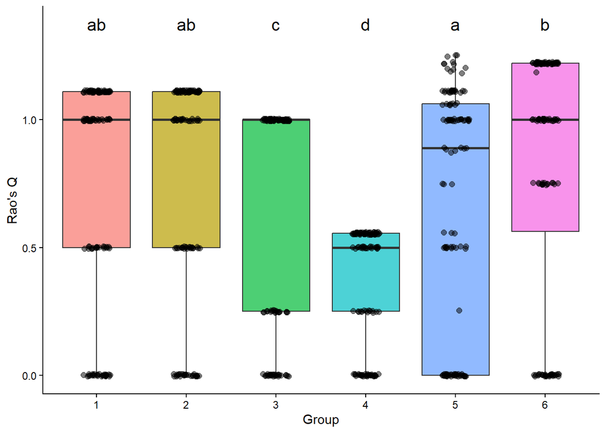

```r
## produce boxplot for RaosQ
RaosQ <- RaoQ(my.sample = abundance, DM = D)
RaosQ_data <- data.frame(
  group = com,
  value = RaosQ
)
fig_raosQ <- Boxplot(
  data = RaosQ_data,
  group_levels = c(
      "1",
      "2",
      "3",
      "4",
      "5",
      "6"
    ),
    ylab = "Rao's Q")
fig_raosQ
```

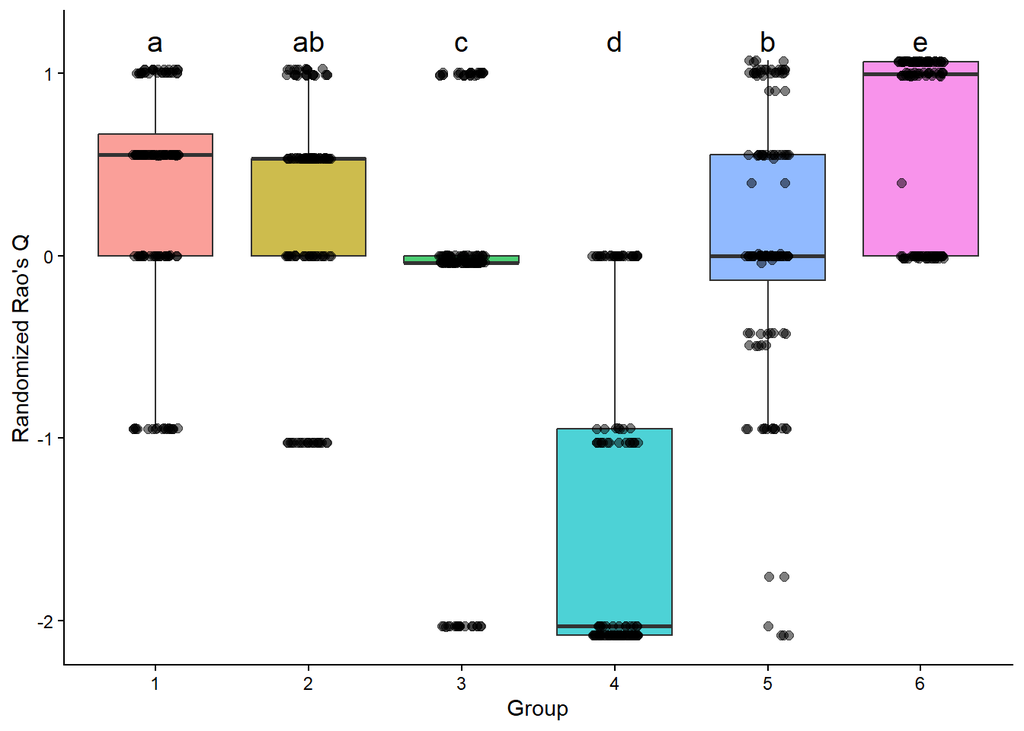

```r
## Produce boxplot for randomized RaosQ
RaosQ_rand <- randomization(
  abundance = abundance,
  DM_phy_func = D
)

# Combine randomized Rao's Q values with community groups.
RaosQ_rand_data <- data.frame(
  group = com,
  value = RaosQ_rand
)

fig1 <- Boxplot(data = RaosQ_rand_data,
                group_levels = c(
       "1",
      "2",
      "3",
      "4",
      "5",
      "6"),
    ylab = "Randomized Rao's Q")
fig1
```

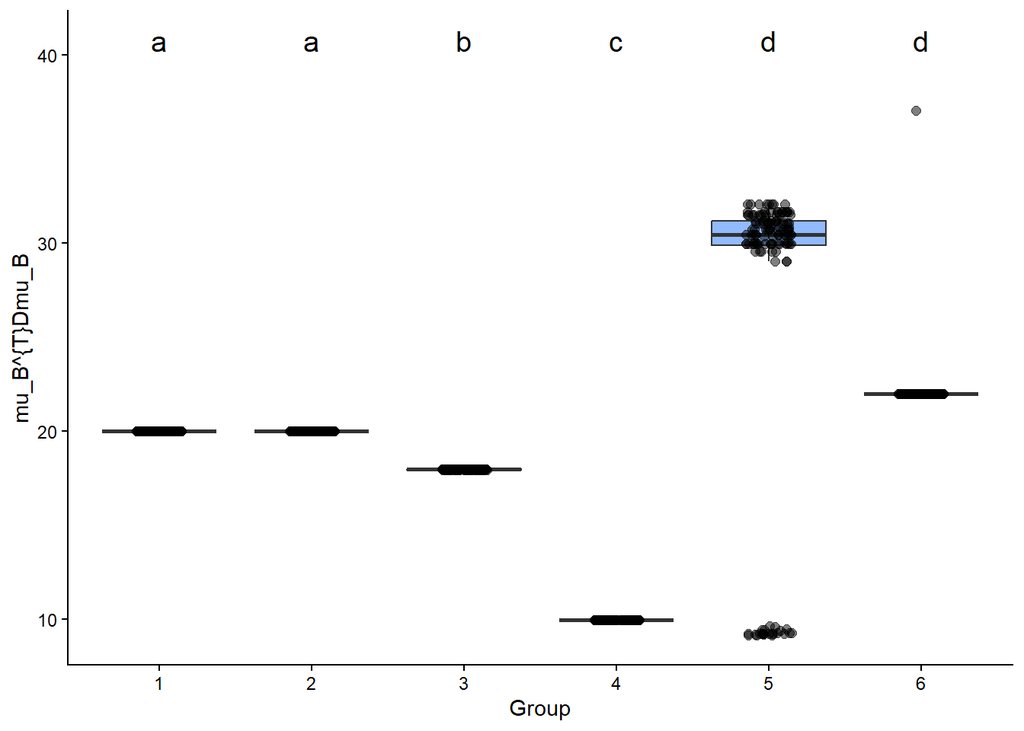

```r
## Produce boxplot for model-based diversity in each com
# Model-based Diversity Assessment
mu_eta_B_u_hat <- expit(eta_B_hat + RR%*%J)
Div_Model <-  rowSums(mu_eta_B_u_hat %*% D * mu_eta_B_u_hat)
Div_Model_data <- data.frame(
  group = com,
  value = Div_Model
)
Boxplot(data = Div_Model_data,
        group_levels = c(
          '1',
          '2',
          '3',
          '4',
          '5',
          '6'),
        ylab = "mu_B^{T}Dmu_B"
        )
```

### Can we visualize relative abundance of each community to show how diversity changes along gradients on a biplot and how the important species contributes to diversity for each community?

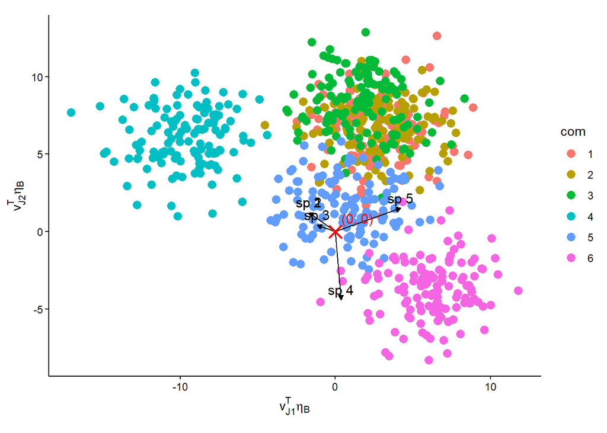

```r
## Produce a biplot based on \eta + u (true parameters)
Biplot(abundance = cbind(com, eta_u_site), P = eigen(J %*% S %*% J)$vectors, plot_labs = labs(
  x = expression(v[J1]^T * eta[B]),
  y = expression(v[J2]^T * eta[B])
), c = 5)
```

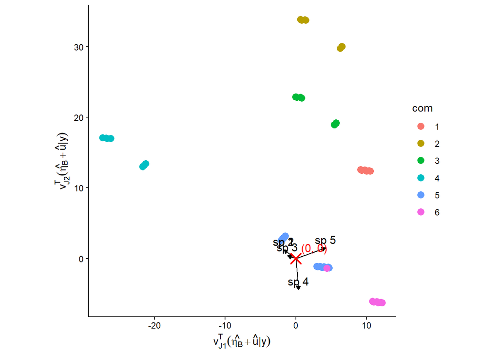

```r
## Produce a biplot based on estimate of \eta_B + u (Estimate \eta_B and u)
eta_T_u_hat  <-  eta_T_hat + RR
colnames(eta_T_u_hat) <- LETTERS[1:5]
Biplot(abundance = cbind(com, eta_T_u_hat), P = eigen(J %*% S %*% J)$vectors, plot_labs = labs(
  x = expression(v[J1]^T * (hat(eta[B]) + hat(u) * "|" * y)),
  y = expression(v[J2]^T * (hat(eta[B]) + hat(u) * "|" * y))
), c = 5)
```

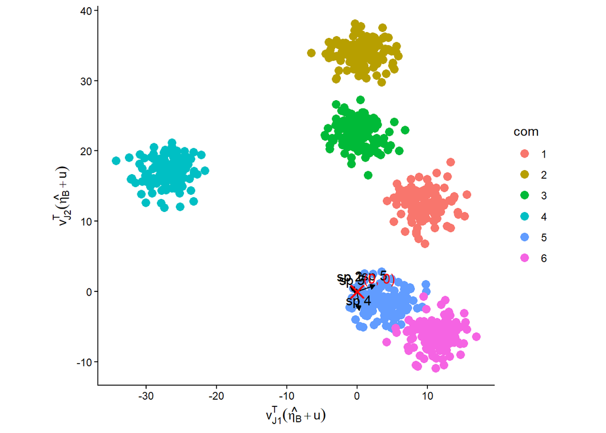

```r
## Produce biplot to project \eta_B_hat + u (Only estimate \eta_B).
eta_T_hat_u <- eta_T_hat + resi_corr
colnames(eta_T_hat_u) <- LETTERS[1:5]
Biplot(abundance = cbind(com, eta_T_hat_u), P = eigen(J %*% S %*% J)$vectors, plot_labs = labs(
  x = expression(v[J1]^T * (hat(eta[B]) + u)),
  y = expression(v[J2]^T * (hat(eta[B]) + u))
))
```